# Linear Regression 1

- Show All Code
- Hide All Code
- View Source

Simple Linear Regression

Author

Affiliation

Daniela Palleschi

Humboldt-Universität zu Berlin

Published

April 13, 2023

# Learning Objectives

Today we will learn…

- the equation of a line
- about intercepts, slopes, and residuals
- how to run our first linear model
- how to interpret model output

# Set-up environment

Make sure you start with a clean R Environment (Session > Restart R).

## Load packages

```r
# suppress scientific notation
options(scipen=999)
```

```r
# load libraries
pacman::p_load(tidyverse,
               broom,
               patchwork,
               knitr,
               kableExtra)
```

## Load in data

- force character variables to factors
- filter for the verb region from critical items only, remove participant 3, and remove values of first-fixtation that are 0

```r
# load in dataset
df_crit_verb <-
  readr::read_csv(
    here::here("data/tidy_data_lifetime_pilot.csv"),
    # for special characters
    locale = readr::locale(encoding = "latin1")
  ) |>
  mutate_if(is.character, as.factor) |> # all character variables as factor
  # mutate(lifetime = fct_relevel(lifetime, "living", "dead"),
  #        tense = fct_relevel(tense, "PP", "SF")) |>
  filter(type == "critical", # only critical trials
         px != "px3", # px3 had a lot of missing values
         fp > 0, # only values of fp above 0
         region == "verb") %>% # critical region only
  droplevels() # remove any factor levels with no observations
```

# Resources

- these slides are based on a mix of the following resources

DeBruine & Barr (2021); Winter (2013); Winter (2014); Winter (2019)

- and on slides that were originally based on Field et al. (2013), but if you’re looking for a textbook I’d recommend Winter (2019)

# 1 Exploratory data analysis (EDA)

- what we’ve learned so far is essentially Exploratory Data Analysis (EDA)
  - visualise your data
  - generate summary (i.e., descriptive) statistics
  - overall getting to know your data, without making any claims beyond your data
- the next step after conducting an EDA is to *model* your data, i.e., run **inferential statistics**
  - this is where we try to generalise beyond our data

# 2 (Linear) Regression

- our data exploration has given us an idea about what our data look like
- but now we want to be able to make predictions about hypothetical observations, i.e., to *predict* values of our DV based on one (or more) IV(s)
  - so we fit a model to our data, and use it to *predict* values of our DV based on one (or more) IV(s)
  - i.e., *predicting* an outcome variable (dependent variable, DV) from one or more predictors (independent variable, IV)
- because we’re making predictions, we need to take into account the variability (i.e., *error*) in our data

## 2.1 Types of regression

| regression type | predictor | outcome |
| --- | --- | --- |
| simple regression | Single predictor | continuous (numerical) |
| multiple regression | multiple predictor | continuous (numerical) |
| hierarchical/linear mixed models/linear mixed effect models | include random effect | continuous (numerical) |
| generalised linear (mixed) models/logistic regression | as above | binary/binomial data or count data |

## 2.2 Straight lines

- *linear regression* summarises the data with a straight line
  - we *model* our data as/fit our data to a straight line
- *straight lines* can be defined by
  - Intercept ($b_0$)
    - value of $Y$ when $X = 0$
  - Slope ($b_1$)
    - gradient (slope) of the regression line
    - direction/strength of relationship between $x$ and $y$
    - regression coefficient for the predictor
- so we need to define an intercept and a slope

### 2.2.1 A line = intercept and slope

- a line is defined by its intercept and slope
  - in a regression model, these two are called `coefficients`

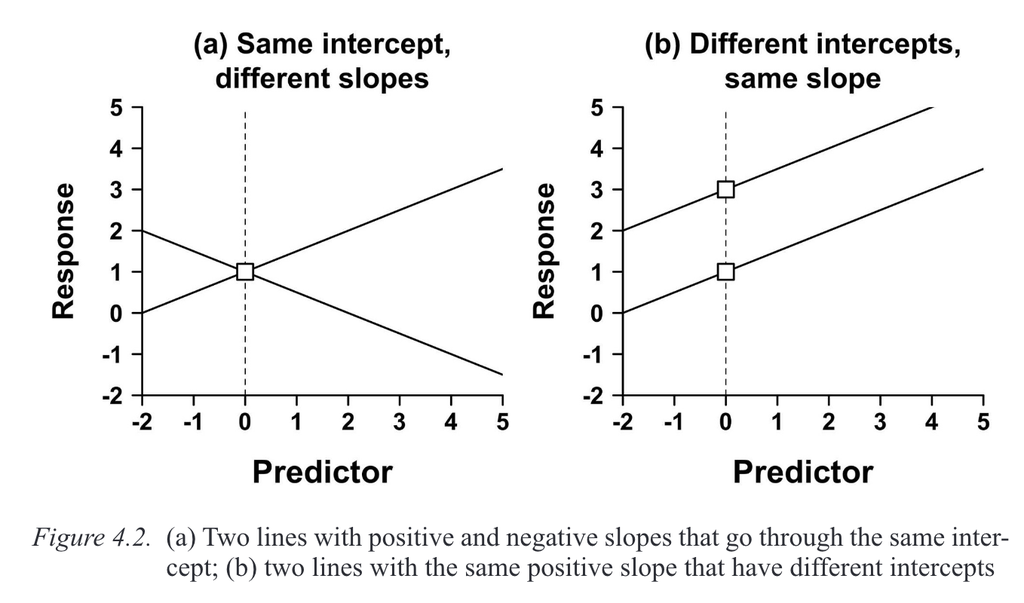

Image source: Winter (2019) (all rights reserved)

### 2.2.2 Intercept ($b_0$)

- the value of $y$ when $x = 0$

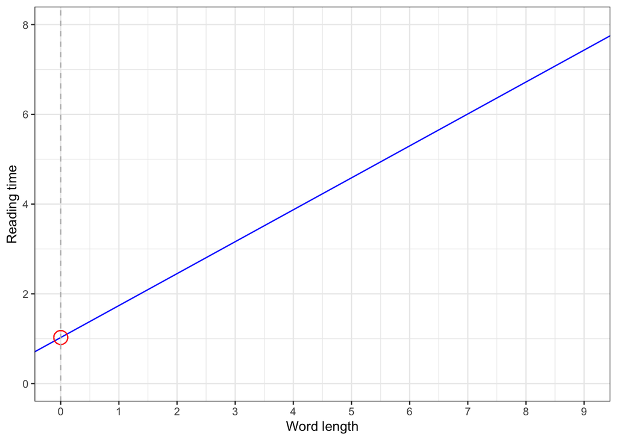

### 2.2.3 Slopes ($b_1$)

- what is the intercept of this line?
- what is the slope of this line?

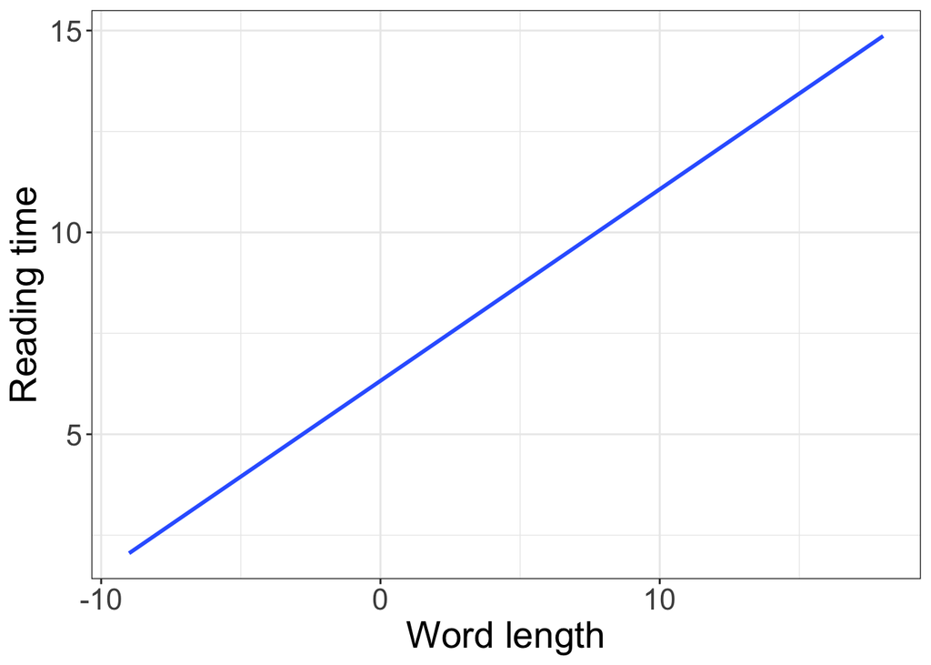

### 2.2.4 Error and residuals

- *fixed effects* (IV/predictors): things we can understand/measure
- *error* (random effects): things we cannot understand/measure
  - in biology, social sciences (and linguistic research), there will always sources of random error that we cannot account for
  - random error is less an issue in e.g., physics (e.g., measuring gravitational pull)
- *residuals*: the difference (vertical difference) between **observed data** and the **fitted values** (predicted values)

**Equation of a line**

$$\begin{align}
y & = mx + c\\
Y_i &= (b_0 + b_1X_i) + \epsilon_i\\
outcome_i & = (model) + error_i\\
y_i & = (intercept + slope*x_i) + error_i
\end{align}$$

### 2.2.5

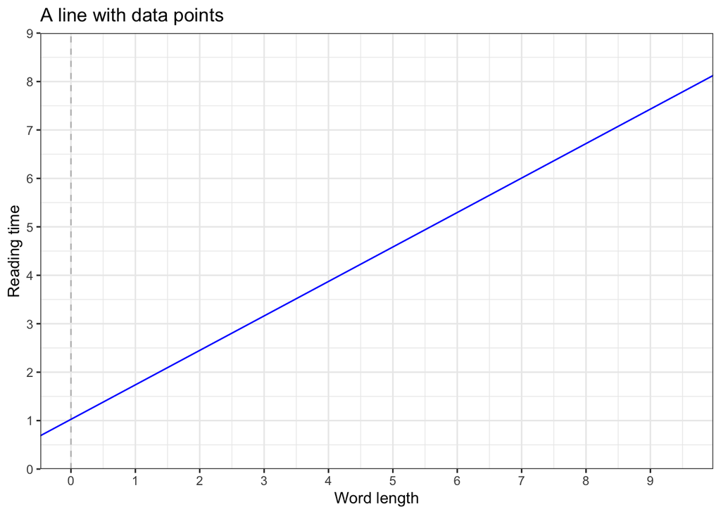

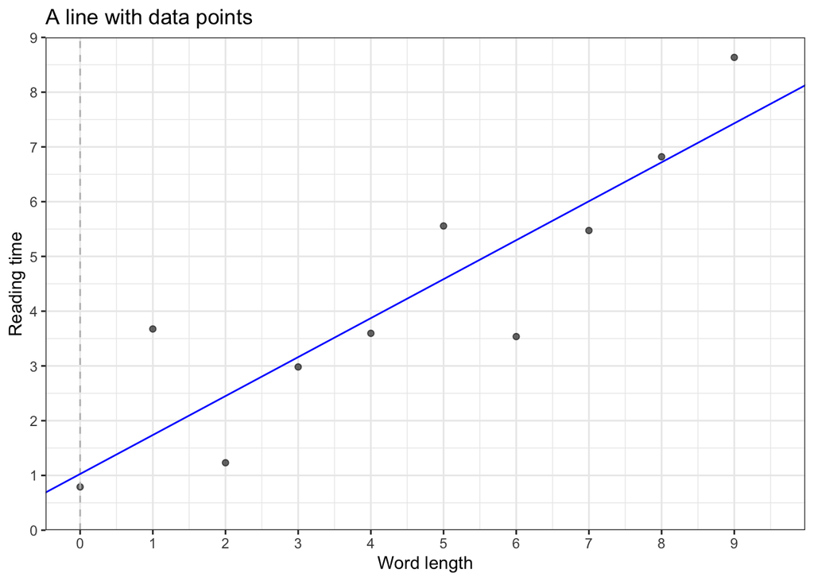

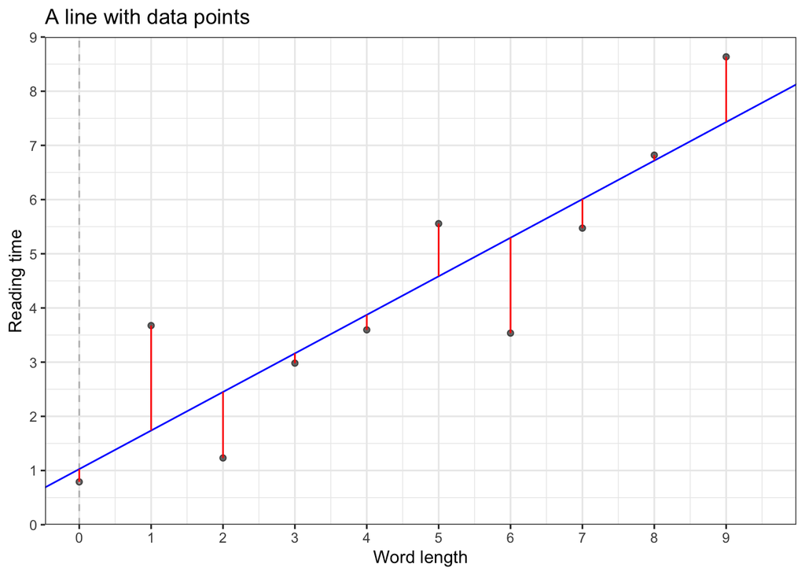

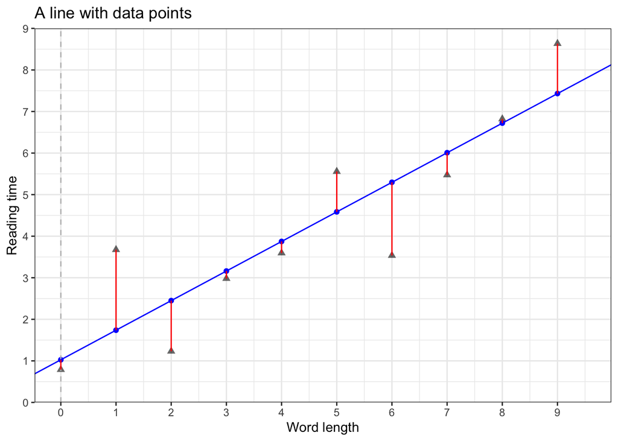

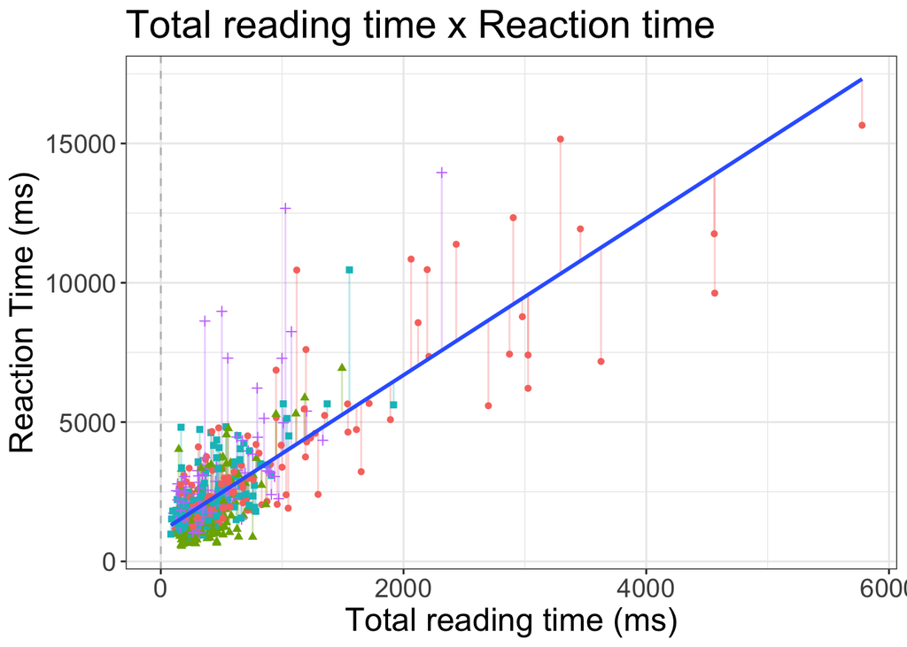

## 2.3 Method of least squares

- so how is any given line chosen to fit any given data?
- the *method of least squares*
  - take a given line, and square all the residuals (i.e., $residual^2$)
  - the line with the lowest *sum of squares* is the line with the best fit to the given data
  - why do we square the residuals before summing them up?
    - so all values are positive (i.e., so that negative values don’t cancel out positive values)
- this is how we find the *line of best fit*
  - R fits many lines to find the one with the best fit

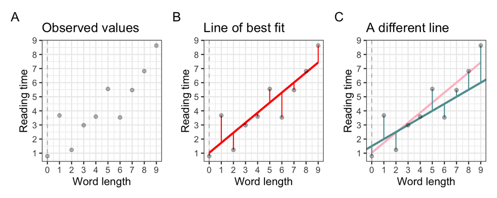

Figure 1: Observed values (A), Residuals for line of best fit (B), A line of worse fit with larger residuals (C)

# 3 Simple linear model: first-pass reading time ~ lifetime

- $y \sim x$ can be read as “y as a function of x”, or “y predicted by x”
- our first model will be:

$$fp \sim lifetime$$

- recall that in our experiment, participants read sentences about `dead` and `living` people in either the English `Simple Future` or `Present Perfect` (2 x2 design)
  - referents (typically) need to exist (i.e., be alive) at reference time (RT)
    - so people who are `dead` are incongruent with the `Present Perfect` (RT = present) and the `Simple Future` (RT = future)
- recall that linking hypotheses take longer reading times to reflect processing costs
  - so, if we’re looking at the `living` versus the `dead` overall, which condition would you hypothesise would attract longer reading times?
- first, let’s plot the data
  - I’m using `position_jitter()` so that all the observations don’t lie on top of each other

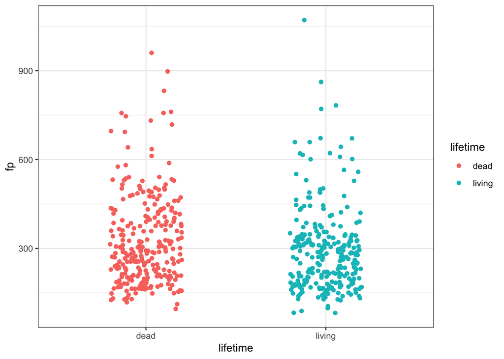

```r
# position_jitter
pj <- position_jitter(0.2)

# plot
df_crit_verb %>%
  filter(region=="verb") %>%
  ggplot(aes(x = lifetime, y = fp, colour = lifetime)) +
  geom_point(position = pj) +
  theme(legend.position = "none") +
  theme_bw()
```

## 3.1 `lm()`

- the `lm()` function fits simple linear models
  - as arguments it takes a formula and a dataset, at minimum

$$lm(outcome \sim 1 + predictor,\;data\;=\;df\_name)$$

- `lm()` function formula syntax can be read as: `fp` predicted by the intercept (`1` is a placeholder for the intercept)
  - the intercept is included by default
  - if you omit the `1`, the intercept is still included in the formula
  - if you wanted to remove the intercept (which you often don’t), you could replace `1` with `0`

### 3.1.1 Running a model

- before we add our predictor `lifetime`, let’s see what our model looks like without it

```r
fit_fp_1 <- lm(fp ~ 1, data = df_crit_verb)
```

### 3.1.2 Model ouput

- printing just the model gives us the formula and the coefficients

```r
fit_fp_1
```

```
Call:
lm(formula = fp ~ 1, data = df_crit_verb)

Coefficients:
(Intercept)
      309.2
```

- recall that the `intercept` and `slope` are called `coefficients`
  - why do we only see `Intercept`?
- we typically use the `summary()` function to print full model outputs

```r
summary(fit_fp_1)
```

```
Call:
lm(formula = fp ~ 1, data = df_crit_verb)

Residuals:
    Min      1Q  Median      3Q     Max
-227.17 -106.17  -26.17   65.83  761.83

Coefficients:
            Estimate Std. Error t value            Pr(>|t|)
(Intercept)   309.17       6.29   49.15 <0.0000000000000002 ***
---
Signif. codes:  0 '***' 0.001 '**' 0.01 '*' 0.05 '.' 0.1 ' ' 1

Residual standard error: 146.6 on 542 degrees of freedom
```

**`broom` package**

- the `broom` package has some useful functions for printing model outputs
  - `tidy()` produces a `tibble` (type of dataframe) of the `coefficients`
  - `glance()` produces goodness of fit measures (which we won’t discuss)
- the outputs from `tidy()` and `glance()` can be fed into `kable` and/or `kable_styling()` to create formatted tables

```r
tidy(fit_fp_1)
```

```
# A tibble: 1 × 5
  term        estimate std.error statistic   p.value
  <chr>          <dbl>     <dbl>     <dbl>     <dbl>
1 (Intercept)     309.      6.29      49.2 7.03e-202
```

```r
glance(fit_fp_1)
```

```
# A tibble: 1 × 12
  r.squared adj.r.squared sigma statistic p.value    df logLik   AIC   BIC
      <dbl>         <dbl> <dbl>     <dbl>   <dbl> <dbl>  <dbl> <dbl> <dbl>
1         0             0  147.        NA      NA    NA -3478. 6960. 6969.
# ℹ 3 more variables: deviance <dbl>, df.residual <int>, nobs <int>
```

- `augment()` adds model values as columns to your dataframe (e.g., useful for plotting observed vs. fitted values)

```r
augment(fit_fp_1, data = df_crit_verb) %>% summary()
```

[output not shown]

### 3.1.3 Interpreting model output

- let’s take a closer look at our model summary

```r
summary(fit_fp_1)
```

```r
Call:
lm(formula = fp ~ 1, data = .)

Residuals:
    Min      1Q  Median      3Q     Max
-227.17 -106.17  -26.17   65.83  761.83

Coefficients:
            Estimate Std. Error t value            Pr(>|t|)
(Intercept)   309.17       6.29   49.15 <0.0000000000000002 ***
---
Signif. codes:  0 ‘***’ 0.001 ‘**’ 0.01 ‘*’ 0.05 ‘.’ 0.1 ‘ ’ 1

Residual standard error: 146.6 on 542 degrees of freedom
```

**1**

formula repetition

**2**

residuals: differences between observed values and those predicted by the model

**3**

names for columns `Estimates`, `standard error`, `t-value`, `p-value` (`Pr(>|t|)`)

**4**

**5**

Significance codes

**6**

### 3.1.4 Intercept

- our intercept is roughly 309.2 milliseconds; what does this number represent?
  - the intercept is essentially the *mean*

```r
# print model intercept?
coef(fit_fp_1)['(Intercept)']
```

```
(Intercept)
   309.1713
```

```r
# print data mean
mean(df_crit_verb$fp)
```

```
[1] 309.1713
```

#### 3.1.4.1 Intercept significance

- in the output, the intercept seems to be significant (indicated with a low p-value, and ***)
  - what does this *mean*?
- significance pretty much tells us if a number is equal to (or not statistically significantly different from) 0
  - so this tells us that the intercept (i.e., the mean first-pass reading time at the verb region) is different from 0
  - most of the time, this isn’t interesting or even theoretically relevant
- the larger your t-value, the smaller your p-value

**A word on t-values and p-values**

*t*-values quantify the *difference* between population means.

*p*-values quantify the probability of obtaining a result equal to or greater than what was observed, given the assumption of no effect (the null hypothesis).

If the null hypothesis were true, we would expect no effect (a flat line). If we have a lot of evidence/are confidence that there is an effect (the line (slope) is in fact *not* flat), then it would be unlikely that we would find such a result under the assumption that there is no effect (the line actually *is* flat) i.e., the null hypothesis. This is reflected in a small p-value.

### 3.1.5 Plotting `fp ~ 1`

- Figure 2 shows the intercept (red dot) amongst the observed data (black dots)
  - along the x-axis we have abstract numerical units (the values don’t mean anything)
  - what would the values of the intercept be?

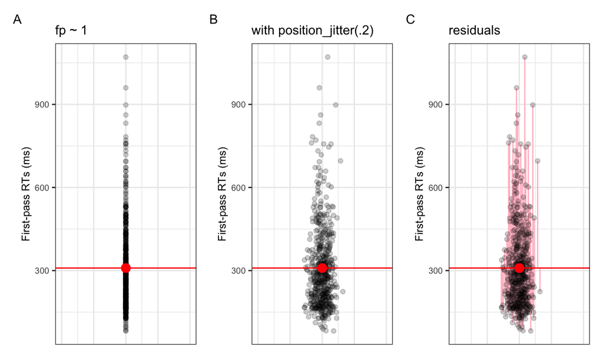

Figure 2: Visualisation of ‘fp ~ 1’: observed values (black) and mean (intercept; red). Residuals would be the distance from each black dot to the y-value of the read dot

## 3.3 Fit model (treatment contrasts)

```r
# fit simple linear model
fit_fp_lifetime_treat <- df_crit_verb %>%
  filter(fp > 0) %>%
  lm(fp ~ lifetime, data = .)
```

```r
# alternatively
fit_fp_lifetime_treat <- lm(fp ~ lifetime,
            data = df_crit_verb, subset = fp > 0)
```

### 3.3.1 Model summary

```r
summary(fit_fp_lifetime_treat)
```

```
Call:
lm(formula = fp ~ lifetime, data = df_crit_verb, subset = fp >
    0)

Residuals:
    Min      1Q  Median      3Q     Max
-228.99 -109.29  -26.99   58.86  777.71

Coefficients:
               Estimate Std. Error t value            Pr(>|t|)
(Intercept)     324.993      8.843  36.752 <0.0000000000000002 ***
lifetimeliving  -31.701     12.517  -2.533              0.0116 *
---
Signif. codes:  0 '***' 0.001 '**' 0.01 '*' 0.05 '.' 0.1 ' ' 1

Residual standard error: 145.8 on 541 degrees of freedom
Multiple R-squared:  0.01172,   Adjusted R-squared:  0.00989
F-statistic: 6.414 on 1 and 541 DF,  p-value: 0.0116
```

### 3.3.2 Intercept

```r
# print model intercept?
coef(fit_fp_lifetime_treat)['(Intercept)']
```

```
(Intercept)
   324.9926
```

```r
# print data mean
mean(df_crit_verb$fp)
```

```
[1] 309.1713
```

- our intercept is no longer the grand mean of first-pass reading times…what is it?

### 3.3.3 Intercept for treatment contrasts

- what are the means of our two factor levels?

```r
# print model intercept?
coef(fit_fp_lifetime_treat)['(Intercept)']
```

```
(Intercept)
   324.9926
```

```r
# compute summary
summary_ff_life <- df_crit_verb |>
  filter(region=="verb",
         fp > 0) |>
  group_by(lifetime) %>%
  summarise(N = n(),
            mean = mean(fp, na.rm = T),
            sd = sd(fp, na.rm = T))

knitr::kable(summary_ff_life, digits=3,
             caption = "Summmary statistics for first-pass reading times at the verb region") %>%
  kableExtra::kable_styling(font_size = 30,
                            position = "left")
```

Summmary statistics for first-pass reading times at the verb region

| lifetime | N | mean | sd |
| --- | --- | --- | --- |
| dead | 272 | 324.993 | 151.005 |
| living | 271 | 293.292 | 140.468 |

### 3.3.4 Slope

- what was our slope?
- what does this correspond to?

```r
# print model intercept?
coef(fit_fp_lifetime_treat)['lifetimeliving']
```

```
lifetimeliving
     -31.70113
```

```r
# compute summary
summary_ff_life <- df_crit_verb |>
  filter(region=="verb",
         fp > 0) |>
  group_by(lifetime) %>%
  summarise(N = n(),
            mean = mean(fp, na.rm = T),
            sd = sd(fp, na.rm = T))

knitr::kable(summary_ff_life, digits=3,
             caption = "Summmary statistics for first-pass reading time at the verb region") %>%
  kableExtra::kable_styling(font_size = 30,
                            position = "left")
```

Summmary statistics for first-pass reading time at the verb region

| lifetime | N | mean | sd |
| --- | --- | --- | --- |
| dead | 272 | 324.993 | 151.005 |
| living | 271 | 293.292 | 140.468 |

- what was our slope?
- what does this correspond to?

| living | dead | diff |
| --- | --- | --- |
| 293.2915 | 324.9926 | -31.70113 |

```r
# compute summary
summary_ff_life <- df_crit_verb |>
  filter(region=="verb",
         fp > 0) |>
  group_by(lifetime) %>%
  summarise(N = n(),
            mean = mean(fp, na.rm = T),
            sd = sd(fp, na.rm = T))

knitr::kable(summary_ff_life, digits=3,
             caption = "Summmary statistics for first-pass reading time at the verb region") %>%
  kableExtra::kable_styling(font_size = 30,
                            position = "left")
```

Summmary statistics for first-pass reading time at the verb region

| lifetime | N | mean | sd |
| --- | --- | --- | --- |
| dead | 272 | 324.993 | 151.005 |
| living | 271 | 293.292 | 140.468 |

# 4 Contrast coding

- intercept: value of $y$ when $x$ = 0
- slope: difference in $y$ with a 1-unit change of $x$
- why is the intercept now the mean of the `dead` condition?
  - when we have a categorical predictor, we cannot calculate a slope because our $x$ is not numerical
  - we need to code factor levels numerically
  - these are called `contrasts`

### 4.0.1 Treatment contrasts

- treatment contrasts (default), aka dummy coding: factor levels are coded as `0` and `1` (alphabetically)
  - all levels are compared to a reference level, coded as `0`
  - so when our predictor ($x$) = 0, this is the first alphabetical level of our factor
  - so our intercept will be the mean `fp` for the lifetime level `dead`
- to check you contrasts:

```r
contrasts(df_crit_verb$lifetime)
```

```
       living
dead        0
living      1
```

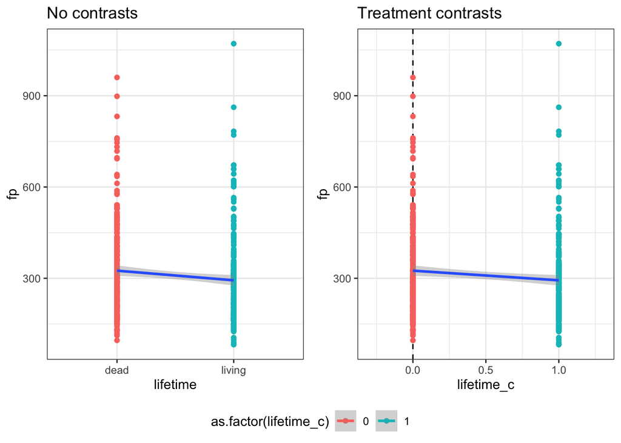

## 4.1 Ordering our contrasts

- but recall that we expected to find *longer* reading times for the `dead` condition
- so the `living` condition is conceptually a baseline, to which we are comparing a violation condition
- it typically makes sense to order your factors in an order that makes the slope easy to interpret
  - we would like a *positive* slope to indicate *longer* reading times for our violation condition
  - so we should have `living` coded as 0, rather than `dead`
- let’s order our predictor
  - we predict longer reading times for dead versus living, so order living-dead

```r
# order factor levels
df_crit_verb$lifetime <- factor(df_crit_verb$lifetime, levels = c("living","dead"))
```

- now what will our contrasts be?

```r
contrasts(df_crit_verb$lifetime)
```

```
       dead
living    0
dead      1
```

## 4.2 Changing our contrasts: sum coding

- now that we know the order of our contrasts, we can also **centre** our predictor
  - we do this because it sometimes makes more sense for the intercept to represent the *grand mean* rather than the mean of one condition (this is especially true when interpreting interactions)
  - to do this, we want 0 to be between our two factor levels
  - e.g., change the contrasts to `-0.5` and `+0.5`
  - for categorical variables, this is called *sum coding*

```r
# set contrasts
contrasts(df_crit_verb$lifetime) <- c(-0.5,+0.5)
```

```r
# print contrasts
contrasts(df_crit_verb$lifetime)
```

```
       [,1]
living -0.5
dead    0.5
```

**Centring continuous predictors**

N.B., you would usually also centre *numeric* predictors. This is done by subtracting some constant from every value (usually by subtracting the mean of the predictor from each value and saving this as a new variable:

```r
df_example %>%
  mutate(predictor_c <- predictor-mean(predictor)
```

If you have interval data with a specific upper and lower bound, you could alternatively subtract the median value.